# F9_02_PREP_PERS_PHONE

Preparer phone · Identifier report

## Overview

**Description**

Paid Preparer Phone

**Table**

`F9-P02-T00-SIGNATURE` (one)

**Location code**

`F990-PC-PART-02`

**Family**

`F990-PC-PART-02` · siblings: F9_02_DISC_PREP_THIRD_PARTY_X, F9_02_PREP_FIRM_ADDR_CITY, F9_02_PREP_FIRM_ADDR_CNTR, F9_02_PREP_FIRM_ADDR_L1, F9_02_PREP_FIRM_ADDR_L2, F9_02_PREP_FIRM_ADDR_STATE

**Data type**

numeric (xsd: PhoneNumberType)

**Scope**

SG

**Status**

unreviewed

3

xpaths mapped (3 observed)

5,473,758

filings with a value

2009–2024

tax years observed

0

open flags (0 errors)

## Flags

No open flags.

## Xpaths

All mapped xpaths (under /Return/ReturnData or /Return/ReturnHeader), oldest first. Charts label each series by its xpath.

| Xpath | Form | First year | Last year | Versions | Filings | Repeats in |
| --- | --- | --- | --- | --- | --- | --- |
| Preparer/Phone | Header | 2009 | 2012 | 18 | 697,399 | 0.0% |
| PreparerPersonGrp/PhoneNum | Header | 2013 | 2024 | 38 | 4,772,982 | 0.0% |
| PreparerPersonGrp/ForeignPhoneNum | Header | 2020 | 2024 | 12 | 3,377 | 0.0% |

## Coverage

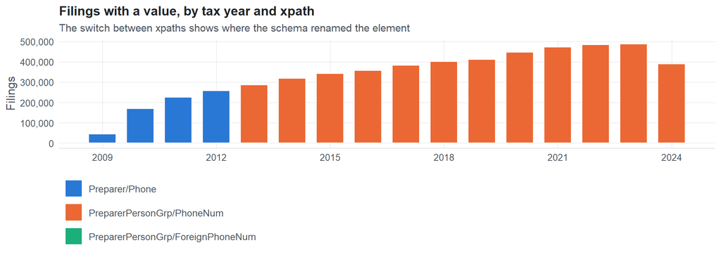

**Table view**

Table view: filings by tax year and series

| Tax year | Preparer/Phone | PreparerPersonGrp/PhoneNum | PreparerPersonGrp/ForeignPhoneNum |
| --- | --- | --- | --- |
| 2009 | 43,849 | 0 | 0 |
| 2010 | 169,765 | 0 | 0 |
| 2011 | 226,121 | 0 | 0 |
| 2012 | 257,664 | 0 | 0 |
| 2013 | 0 | 285,829 | 0 |
| 2014 | 0 | 317,626 | 0 |
| 2015 | 0 | 341,464 | 0 |
| 2016 | 0 | 357,109 | 0 |
| 2017 | 0 | 382,456 | 0 |
| 2018 | 0 | 400,999 | 0 |
| 2019 | 0 | 411,364 | 0 |
| 2020 | 0 | 447,126 | 114 |
| 2021 | 0 | 472,118 | 248 |
| 2022 | 0 | 482,992 | 859 |
| 2023 | 0 | 486,099 | 1,154 |
| 2024 | 0 | 387,800 | 1,002 |

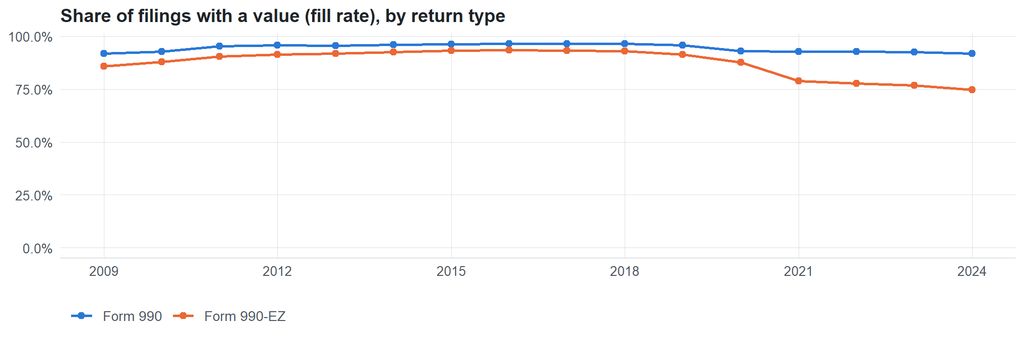

**Table view**

Table view: fill rate

| Tax year | Return type | Filings | All filings | Fill rate |
| --- | --- | --- | --- | --- |
| 2009 | Form 990 | 30,568 | 33,311 | 91.77% |
| 2009 | Form 990-EZ | 13,281 | 15,470 | 85.85% |
| 2010 | Form 990 | 114,132 | 123,025 | 92.77% |
| 2010 | Form 990-EZ | 55,633 | 63,326 | 87.85% |
| 2011 | Form 990 | 151,929 | 159,504 | 95.25% |
| 2011 | Form 990-EZ | 74,192 | 82,048 | 90.43% |
| 2012 | Form 990 | 171,998 | 179,688 | 95.72% |
| 2012 | Form 990-EZ | 85,666 | 93,750 | 91.38% |
| 2013 | Form 990 | 189,903 | 198,855 | 95.50% |
| 2013 | Form 990-EZ | 95,926 | 104,375 | 91.91% |
| 2014 | Form 990 | 209,937 | 218,619 | 96.03% |
| 2014 | Form 990-EZ | 107,689 | 116,417 | 92.50% |
| 2015 | Form 990 | 224,979 | 233,519 | 96.34% |
| 2015 | Form 990-EZ | 116,485 | 124,894 | 93.27% |
| 2016 | Form 990 | 235,176 | 243,903 | 96.42% |
| 2016 | Form 990-EZ | 121,933 | 130,484 | 93.45% |
| 2017 | Form 990 | 252,617 | 261,612 | 96.56% |
| 2017 | Form 990-EZ | 129,839 | 139,144 | 93.31% |
| 2018 | Form 990 | 262,082 | 271,442 | 96.55% |
| 2018 | Form 990-EZ | 138,917 | 149,384 | 92.99% |
| 2019 | Form 990 | 271,899 | 283,694 | 95.84% |
| 2019 | Form 990-EZ | 139,464 | 152,622 | 91.38% |
| 2020 | Form 990 | 298,132 | 320,342 | 93.07% |
| 2020 | Form 990-EZ | 149,106 | 169,864 | 87.78% |
| 2021 | Form 990 | 312,649 | 336,480 | 92.92% |
| 2021 | Form 990-EZ | 159,704 | 202,724 | 78.78% |
| 2022 | Form 990 | 323,804 | 349,055 | 92.77% |
| 2022 | Form 990-EZ | 160,036 | 206,130 | 77.64% |
| 2023 | Form 990 | 328,621 | 354,768 | 92.63% |
| 2023 | Form 990-EZ | 158,623 | 206,379 | 76.86% |
| 2024 | Form 990 | 255,073 | 277,298 | 91.99% |
| 2024 | Form 990-EZ | 133,724 | 178,867 | 74.76% |

## Values

| Result | Check | Detail |
| --- | --- | --- |
| ✓ pass | Values have the Phone format | 100.0% of values match ^9999999999$ |
| ⚠ fail | Stored as text | data type is numeric: leading zeros and letters would be lost |
| ✓ pass | No placeholder values | no all-zero / all-nine placeholders among the most common values |
| ✓ pass | Leading zeros present | no evidence of leading zeros |

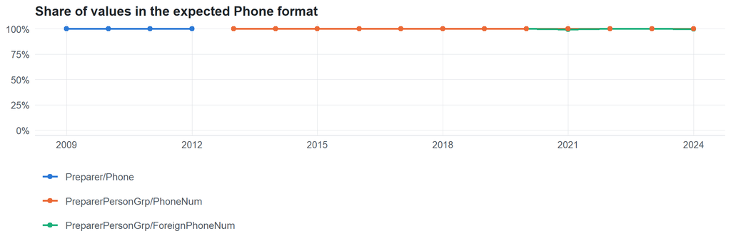

Value shapes (9 = digit, A = letter)

| Series | Shape | Expected | Filings |
| --- | --- | --- | --- |
| Preparer/Phone | 9999999999 | yes | 697,399 |
| PreparerPersonGrp/PhoneNum | 9999999999 | yes | 4,772,982 |
| PreparerPersonGrp/ForeignPhoneNum | 9999999999 | yes | 3,375 |
| PreparerPersonGrp/ForeignPhoneNum | 99999999999 | no | 2 |

## Examples

| Tax year | Return | Xpath | Organization | Value | Source |
| --- | --- | --- | --- | --- | --- |
| 2024 | 990 | PreparerPersonGrp/ForeignPhoneNum | MINISINK HOSE COMPANY NO 1 INC | 3154288344 | [XML](https://gt990datalake-rawdata.s3.amazonaws.com/EfileData/XmlFiles/202531279349302268_public.xml) |
| 2024 | 990EZ | PreparerPersonGrp/PhoneNum | SAINT CLAIR HOUSE INC | 2163630100 | [XML](https://gt990datalake-rawdata.s3.amazonaws.com/EfileData/XmlFiles/202521329349201597_public.xml) |
| 2023 | 990 | PreparerPersonGrp/ForeignPhoneNum | SOUTHEAST ARLINGTON LITTLE LEAGUE | 8179143578 | [XML](https://gt990datalake-rawdata.s3.amazonaws.com/EfileData/XmlFiles/202530479349300428_public.xml) |
| 2023 | 990EZ | PreparerPersonGrp/PhoneNum | SAN ANTONIO HOMESCHOOL ATHLETIC ASSOICATION | 2109225200 | [XML](https://gt990datalake-rawdata.s3.amazonaws.com/EfileData/XmlFiles/202432609349201843_public.xml) |
| 2022 | 990EZ | PreparerPersonGrp/ForeignPhoneNum | VICTORY MOTORCYCLE CLUB INC | 3525852083 | [XML](https://gt990datalake-rawdata.s3.amazonaws.com/EfileData/XmlFiles/202343199349200524_public.xml) |
| 2022 | 990 | PreparerPersonGrp/PhoneNum | MERRILL COMMUNITY HOMELESS CENTER INC | 7155368328 | [XML](https://gt990datalake-rawdata.s3.amazonaws.com/EfileData/XmlFiles/202331589349300003_public.xml) |
| 2021 | 990EZ | PreparerPersonGrp/ForeignPhoneNum | BRADY S BRIDGE INC | 5129245291 | [XML](https://gt990datalake-rawdata.s3.amazonaws.com/EfileData/XmlFiles/202201369349208930_public.xml) |
| 2021 | 990EZ | PreparerPersonGrp/PhoneNum | BLAINE 1 INC | 4063572149 | [XML](https://gt990datalake-rawdata.s3.amazonaws.com/EfileData/XmlFiles/202201369349200340_public.xml) |
| 2020 | 990EZ | PreparerPersonGrp/ForeignPhoneNum | MISSION ONE MILLION | 8587508346 | [XML](https://gt990datalake-rawdata.s3.amazonaws.com/EfileData/XmlFiles/202103389349200300_public.xml) |
| 2020 | 990EZ | PreparerPersonGrp/PhoneNum | GENESEE TOWNSHIP VETERANS MEMORIAL | 8107362350 | [XML](https://gt990datalake-rawdata.s3.amazonaws.com/EfileData/XmlFiles/202142879349200014_public.xml) |
| 2019 | 990EZ | PreparerPersonGrp/PhoneNum | CRESSKILL COUGARS UNITED SOCCER | 2015679188 | [XML](https://gt990datalake-rawdata.s3.amazonaws.com/EfileData/XmlFiles/202013089349200306_public.xml) |
| 2018 | 990 | PreparerPersonGrp/PhoneNum | Coalition for Responsible Waste Incineration | 7039729110 | [XML](https://gt990datalake-rawdata.s3.amazonaws.com/EfileData/XmlFiles/201902539349301225_public.xml) |

## Reviewer checklist

- The definition matches the form line and instructions for every xpath’s schema years.
- Every xpath pooled here measures the same thing on the 990 and 990-EZ (close enough for analysis).
- The coverage chart has no unexplained gaps or jumps between tax years.
- Each open flag is fixed, or accepted with a note in validation_log.csv.
- The data type is text so leading zeros and letters survive.
- The identifier belongs to the entity the variable names (the filer, preparer, related organization…).
- Formats with and without punctuation (e.g. ZIP+4, dashes) are normalized consistently downstream.

Record the review as a row in `inst/extdata/src/validation_log.csv` (variable_name, reviewer, date, status, note). Evidence built 2026-09-23 17:09:04 MST from the ef2 DuckDB builds (tax years 2009–2024).